Nº 01 · Vol. 26 Ciencias sociales · Datos · R

# Una oficina *de análisis* en voz alta.

**La Datáfora** es el cuaderno abierto de **Gonzalo Almendariz Villanueva**, analista de datos e investigador social. Reúne paquetes de R, materiales didácticos y proyectos aplicados con un enfoque reproducible.

Ver el perfil → Explorar Prosecnur

Proyectos 12 activos · 2024–26

Paquetes R 2 IncoreR · Prosecnur

Capítulos 9 libro en curso

Cursos 5 dictados desde 2024

§ 01 / Despachos

## Líneas de trabajo en curso

Tres proyectos abiertos donde se combina investigación, herramientas en R y pedagogía.

PAQUETE R · 2025Prosecnur

### Automatizar la *limpieza* y la consistencia de encuestas XLSForm.

A partir del cuestionario, Prosecnur genera reglas de validación, detecta saltos mal aplicados y produce reportes reproducibles. Nació en proyectos con ACNUR; sirve a cualquier estudio que priorice trazabilidad.

→ prosecnur.htmlv0.3.1

LIBRO · 2025R · Estadística

### R para el *análisis* de datos.

Nueve capítulos que recorren desde la medición y exploración hasta regresión, con ejemplos reproducibles en R pensados para las ciencias sociales.

9 capítulosES · libre

DOCENCIA · 2024–R · ggplot

### Enseñar el *criterio* antes que la fórmula.

Cursos dictados en UP, UNMSM, Municipalidad de Lima y Métrica 23. Flujos reproducibles, gramática de datos y visualización como lectura.

+300 est.ES

§ 02 / Corpus

## Publicaciones, paquetes y cursos

Un índice rastreable. Cada pieza enlaza a su manual, repositorio o reporte.

- 001 Prosecnur *· validador de XLSForm*Paquete R · limpieza + consistencia + reportes R · Quarto · v0.3.1 MANUAL →
- 002 IncoreR *· competitividad regional*Índice de Competitividad Regional (IPE) · Perú R · Shiny · 2025 MANUAL →
- 003 R para el análisis de datos *· libro*Nueve capítulos, del dato crudo a la inferencia Libro libre · 2025 LEER →
- 004 Voces para el Futuro *· PNUD–CAF*STM sobre ~1,000 respuestas abiertas en LAC PLN · STM · 2024 REPORTE →
- 005 Elecciones 2021 *· Ley de Benford*Lectura prudente de integridad electoral R · tidyverse · 2023 REPORTE →
- 006 Pensión 65 *· gráficos*Visualizaciones comparables por subgrupo y región ggplot2 · 2024 GRÁFICOS →

§ 03 / Posición

## Una lectura del oficio

> Trabajar con datos no es producir certidumbre  
> sino diseñar *preguntas* que se sostengan  
> cuando el método las empieza a doblar. — Gonzalo Almendariz V.

Años con R 07 desde 2019

Encuestas procesadas +40 proyectos aplicados

Paquetes publicados 02 con documentación

Alumnado +300 en cursos propios

§ 04 / Pieza destacada

## El libro

Un manual libre para quien enseña, investiga o estudia con datos en ciencias sociales.

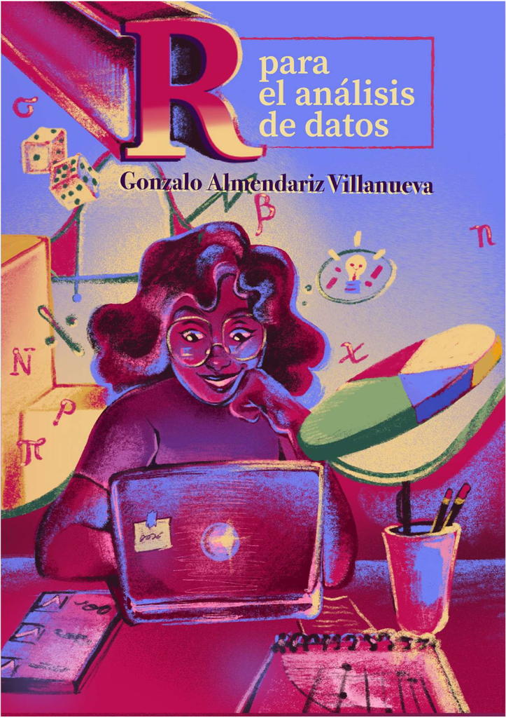

La Datáfora · Vol. 01Primera edición

Libro libre · primera edición en curso · español

### *R* para el análisis de datos

R al alcance de todas y todos — estadística aplicada a las ciencias sociales

Más que un manual técnico, es una guía práctica para comprender los fundamentos de la estadística descriptiva e inferencial y para incorporarlos al trabajo empírico mediante R. Cada capítulo entrega teoría, ejemplos aplicados y código reproducible para fortalecer la autonomía analítica y el criterio crítico en el uso de los datos.

Fundamentos & medición

Exploración de datos

Estadística descriptiva

Probabilidad

Distribuciones

Inferencia

Pruebas de hipótesis

Regresión lineal

Comunicación

Leer online → Ver GitHub

§ 05 / Índice de términos

## La materia prima

Las herramientas y lenguajes que recorren este cuaderno.

*R* & tidyverse— 0001 · eje central

Quarto*reproducibilidad*— 0002 · cada reporte corre solo

ggplot2, *dplyr*, tidyr— 0003 · gramática

Shiny & *interactividad*— 0004 · IncoreR web

XLSForm · KoBo · *ODK*— 0005 · campo

PLN & *STM*— 0006 · respuestas abiertas

§ 06 / Ahora

## *Hoy*, qué hay en la mesa

Puesto **Analista de datos** en PULSO PUCP proyectos con ACNUR · movilidad humana

Escribiendo *Capítulo 07* — Pruebas de hipótesis última revisión · abr · 2026

Buscando Colaboraciones puntuales en *investigación*, visualización o docencia contacto · gonzaloalmendariz@gmail.com